# Final project code

Laura Zhou, Shaina Mitchell, Peiyao Wang

11/16/2017

# Introduction

For our final project, we aimed to confirm and explore the results in Figure 6 of the paper “CoINcIDE: A framework for discovery of patient subtypes across multiple datasets.” We are interested in identifiying latent subtypes in breast cancer and explore how `hclust` and `mclust` results compare with the new CoINcIDE method.

## Background on Breast Cancer

Breast cancer is a heterogeneous disease composed of a growing number of recognized biological subtypes. One way to detect cancer subtypes is through the analysis of gene expression. Detecting cancer subtypes can be beneficial to both the medical and statistical industry. Gene expression studies using DNA microarrays have identified several distinct breast cancer subtypes; these subtypes differ markedly in prognosis and in the repertoire of therapeutic targets they express. Gene expression patterns can stratify patients into subtypes with distinct survival patterns; such subtypes have the potential to drive personalized patient treatment regimens and risk prediction models.

## CoiNcide Paper Reivew

The paper “CoINcIDE: A framework for discovery of patient subtypes across multiple datasets” uses the dataset `curatedBreastData`, which is available as an R package. This paper presents a new method, CoINcIDE, which identifies patient subtypes through unsupervised clustering across multiple datasets. This provides more clinical utliltity that most current methods are unable to repliate. CoINcIDE discovers replicable patient subtypes by finding agreement across dataset-specific clusterings from multiple datasets. It clusters individual datasets, represented as nodes in a network, and assigns edges between similar clusters across data sets to create a network, then it identifies the subtypes through community detection. These final subtypes are defined by meta-clusters of tightly connected clusters within this network. An additional advantage of CoINcIDE is that it requires no between-dataset transformations.

## Project Objectives

The primary objectives our our paper were to (1) to determine number of latent subtypes, (2) to determine number of samples in each subtype, and (3) compare with COINCIDE paper. Specifically, we want to explore the effect of transformations on the subtype clusters by comparing clustering results of hclust and mclustBIC.

## Figure 6 Discussion

We decided to recreate Figure 6 from the paper for our project. This figure demonstrates the clustering that resulted from using various clustering techniques: the proprietary CoINcIDE technique, naive clustering with no transformation, Batch Mean Centering, and ComBat. The idea in the paper was to try to recover the established PAM50 subtypes. In the event of differences, the results would be used to suggest that unsupervised machine learning methods had predicted a more sentitive subtyping than the commonly accepted ones. While in class we learned about ‘hclust’ which heuristically groups units based on closeness characteristics, for this project we opted to use ‘mclust’ which is a model-based clustering algorithm so that we could use a criterion like BIC to select the number of classes, which is not possible with the results of ‘hclust’. However, we recognize that the model may be incorrectly specified, and so for each clustering method we used in this project, we also included a figure comparing ‘mclust’ and ’hclust results.

# Data Management

Data management of the CuratedBreastData involved applying three filters to achieve the same analysis dataset as was used in the study. The three criteria were:

- only include datasets with at least 30 samples were to be included
- only include datasets that included the minimum 35 genes of the PAM50 genes
- within a dataset, in the event that information on a gene was collected more than once, only include the version with the highest variance

These filtering steps resulted in the attrition from 34 original datasets to 17 datasets to be used for the subsequent analysis.

```r
#source("https://bioconductor.org/biocLite.R")
#biocLite("curatedBreastData")

library("curatedBreastData")
library(SummarizedExperiment)
library(Biobase)

data(curatedBreastDataExprSetList)
cbd <- curatedBreastDataExprSetList
#str(cbd[[1]])
str <- unique(protocolData(cbd[[1]])$labelDescription)

grepl("breast", str, ignore.case=T)
```

```
## [1] TRUE
```

```r
#===================================# Getting the same dataset #=====================================#
#===# apply filters
samp.size <- sapply(1:length(cbd), function(i) nrow(protocolData(cbd[[i]])))
cut1 <- samp.size > 30 # checking which/how many have at least 30 samples

 #== making the first cut
names.cut1 <- names(cbd)[cut1]
cbd.cut1 <- cbd[names.cut1]

all.t <- sapply(1:34, function(i) strsplit(as.character(unique(phenoData(cbd[[i]])$datasetName)), "_")[[1]][2])
datnCuts <- cbind(all.t, cut1) # all genes and which made first cut
geo.plat.id <- sapply(1:34, function(i) strsplit(as.character(unique(phenoData(cbd[[i]])$datasetName)), "_")[[1]][3])

batch.id0 <- sapply(1:34, function(i) strsplit(as.character(unique(phenoData(cbd[[i]])$datasetName)), "_")[[1]][4])
batch.id <- ifelse(batch.id0 == "all", "", batch.id0)
#featureData(cbd[[1]])$probe

#namesofthing <- sapply(1:34, function(i) as.character(unique(phenoData(cbd[[i]])$datasetName)))


dat1 <- subset(cbd, subset=c(cut1 == 1))

#== making the second cut
# pam50 gene set
gs0 <- c("GRB7 CEP55 MYBL2 KRT5 CDC20 UBE2C CDH3 EXO1 MELK MIA KRT14 BAG1 BIRC5 BLVRA CCNB1 CCNE1 CDC6 CENPF EGFR ERBB2 ESR1 FOXA1 FOXC1 KIF2C KRT17 MAPT MDM2 MKI67 MMP11 MYC PGR RRM2 SFRP1 SLC39A6 TYMS")
gs <- unlist(strsplit(gs0, " "))
length(gs)
```

```
## [1] 35
```

```r
cut2 <- sapply(1:length(cbd), function(i) all(gs %in% featureData(cbd[[i]])$gene_symbol))

# summary of which experiments made which cuts
datnCuts <- data.frame(all.t, cut1, cut2)
datnCuts[["both.cuts"]] <- with(datnCuts, cut1*cut2)
datnCuts[["sampsize"]] <- samp.size
datnCuts[["real.cut"]] <- with(datnCuts, cut2*(sampsize > 47))
datnCuts[["batch.id"]] <- batch.id
datnCuts[["geo.plat.id"]] <- geo.plat.id

datnCuts
```

```
##    all.t  cut1  cut2 both.cuts sampsize real.cut batch.id geo.plat.id
## 1   1379  TRUE  TRUE         1       60        1              GPL1223
## 2   2034  TRUE  TRUE         1      286        1                GPL96
## 3   4913  TRUE FALSE         0       50        0              GPL3558
## 4   6577  TRUE FALSE         0       88        0              GPL3883
## 5   9893  TRUE  TRUE         1      155        1              GPL5049
## 6  12071  TRUE  TRUE         1       46        0              GPL5186
## 7  12093  TRUE  TRUE         1      136        1                GPL96
## 8  16391  TRUE  TRUE         1       48        1               GPL570
## 9  16446  TRUE  TRUE         1      114        1               GPL570
## 10 17705  TRUE  TRUE         1      103        1      JBI       GPL96
## 11 17705  TRUE  TRUE         1      195        1    MDACC       GPL96
## 12 18728 FALSE  TRUE         0       21        0               GPL570
## 13 19615  TRUE  TRUE         1      115        1               GPL570
## 14 19697 FALSE  TRUE         0       24        0               GPL570
```

[output cut: 20 more lines]

```r
# dataset with only those experiments that made both cuts
dat <- cbd[datnCuts$real.cut == 1]
```

Below is a summary of the datasets used in our analysis. As seen in Table 1 of the paper, we have obtained the same datasets.

```r
#Table 1: Summary of our dataset
table1 <- datnCuts[datnCuts$real.cut==1, c("all.t","batch.id","geo.plat.id","sampsize")]
names(table1) <- c("ID","Batch ID","GEO Platform ID","Samples (n)")
table1
```

```
##       ID Batch ID GEO Platform ID Samples (n)
## 1   1379                  GPL1223          60
## 2   2034                    GPL96         286
## 5   9893                  GPL5049         155
## 7  12093                    GPL96         136
## 8  16391                   GPL570          48
## 9  16446                   GPL570         114
## 10 17705      JBI           GPL96         103
## 11 17705    MDACC           GPL96         195
## 13 19615                   GPL570         115
## 15 20181                    GPL96          53
## 16 20194                    GPL96         261
## 21 22226                  GPL1708         129
## 23 22358                  GPL5325         122
## 25 25055    MDACC           GPL96         221
## 28 25065    MDACC           GPL96          71
## 32 25065      USO           GPL96          54
## 33 32646                   GPL570         115
```

Before we can run our project analysis on the dataset, there was one more filter that had to be applied. The format of the final datasets should only be the last 35 genes

```r
#== instructions for removing duplicate genes_symbols
# For duplicated gene symbols linked to different probes in an array, the probe linked to that
# specific gene with the highest variance across all samples was kept.
# Additional Files 2

#=== FUNCTION: data.ready
# OBJECTIVE: for one dataset, this returns the 35 pam50 genes with the largest variance
# INPUTS:  one dataset from dat
# OUTPUT: dataset without replicates
data.ready <- function(dat){
  jnk <- dat
  jnk2 <- featureData(jnk)$gene_symbol %in% gs

  jnk.gs <- featureData(jnk)$gene_symbol
  jnk.vars <- apply(exprs(jnk), 1, function(x) var(x, na.rm=TRUE))

  thing <- data.frame(jnk.gs, jnk.vars)
  thing2 <- thing[thing$jnk.gs %in% gs,]

  #=== FUNCTION: compare.to.max
  # OBJECTIVE: compare the value in a row of a matrix to the max value in the cluster
  # INPUTS: the dataset (data), the row index (i), the cluster variable (clust)
  # OUTPUTS: indicator variable of whether the given row matches the cluster max
  compare.to.max <- function(i, data=thing2, clust="jnk.gs"){
    d <- data[[clust]]
    c <- d[i]
    max.c <- max(data[d == c,"jnk.vars"])
    is.max <- as.numeric(data[i,"jnk.vars"] == max.c)

    return(is.max)
  }

  is.max <- sapply(1:nrow(thing2), compare.to.max)

  thing3 <- data.frame(thing2, is.max)

  final0 <- jnk[jnk2==TRUE,]
  final <- final0[thing3$is.max==1,]

  # o <- match(gs, thing3$jnk.gs[thing3$is.max==1])
  # final <- final[o,]
  # rownames(final) <- gs
  return(final)
}
```

Thus, our final 17 datasets are created below using the functions defined above.

```r
# the unconcatenated final analysis data set
data.uncat <- lapply(1:length(dat), function(i) {d <- data.ready(dat[[i]])
                                                  n.d <- featureData(d)$gene_symbol
                                                  d2 <- exprs(d)
                                                  study.name <- phenoData(d)$datasetName
                                                  colnames(d2) <- paste(i, "_", colnames(d2), sep="")
                                                  rownames(d2) <- n.d
                                                  return(d2)})
## NOTE:!!! This is something I corrected for in the clustering2 function
# there are na values in the 12th and 13th study
# find where the na values are and remove those
# 12
id.na.12 = which(is.na(data.uncat[[12]]))
# rowid.na.12 = (id.na.12 - 1)%%35 + 1
# col id of the na values
colid.na.12 = ceiling(id.na.12/35)

# remove the columns with na values
data.uncat[[12]] = data.uncat[[12]][, -unique(colid.na.12)]

# 13
id.na.13 = which(is.na(data.uncat[[13]]))
# rowid.na.13 = (id.na.13 - 1)%%35 + 1
colid.na.13 = ceiling(id.na.13/35)
data.uncat[[13]] = data.uncat[[13]][, -unique(colid.na.13)]
```

# Data Analysis

To observe our final 17 datasets, we create histograms for each study of the counts, summarized in Figure 1 below.

[figure not shown]

```r
#Figure 1
par(mfrow=c(3,6), mar=c(5,3,3,1))
for(i in 1:17)
 hist(unlist(data.uncat[[i]]), main=paste("Study", all.t[[i]]), xlab="counts")
par(mfrow=c(1,1))
```

To run the analysis in each of the tasks described above, we will use the `clustering` functions below.

```r
library(matrixStats)
library(dendextend)
library(RColorBrewer)
library(DESeq2)
library(mclust)
```

```r
# FUNCTION: clustering2
# OBJECTIVE: to create 4 plots detailing results of hclust (colored by mclust results),
#            # clusters for mclust determined by BIC,
#            mclust classification and centroids in 2-D,
#            and number of samples in each mclust cluster
# INPUTS: dataset and data.type (what type of transformation was used)
# OUTPUS: 2x2 plot of 4 elements and mclust object
clustering2 <- function(data, data.type){
  par(mfrow=c(2,2))
  where.nas <- is.na(colMeans(data))
  data0 <- data[,where.nas == FALSE]
  dat11 <- t(as.matrix(data0))
  dists <- dist(dat11)

  hc <- hclust(dists, method="complete")
  dend <- as.dendrogram(hc)
  o.dend <- order.dendrogram(dend)

  #using mclust
  mod.BIC = mclustBIC((dat11))
  mod1 = Mclust(dat11, x = mod.BIC)
  cols <- brewer.pal(length(unique(mod1$classification)), "Set1")


  ####plotting the dendrogram
  #color by mclust catebory
  labels_colors(dend) <- cols[mod1$classification[o.dend]]
  plot(dend, main=paste("Heuristic Clustering of\n", data.type, "Data\nby mclust classification")) #all.t contains study labels


  ####plotting mclust
  plot(mod.BIC)
  title("Number of Components\nSelected by BIC")
  plot(mod1, what = "classification", dimens=c(2,1), main="", col=cols)
  title("Mclust Classification and Centroids")

  ####bargraph of muclust
  a=table(mod1$classification)
  barplot(a, main="Number of Samples\nin Each mclust Class", ylim=c(0,nrow(dat11)), col=cols)
  return(mod1)
}
```

## Task 1: Clustering within each Study

In our first task, we are interested in establishing the latent subtypes within each of the studies using `mclustBIC`. Since the `mclust` function takes time to run, we ran the following code below which outputs all the `mclustBIC` into object `clustList`. Below is the code we ran outside of this Rmarkdown.

```r
#function that outputs the mclust output
clusteringFunc <- function(data){
  where.nas <- is.na(colMeans(data))
  data0 <- data[,where.nas == FALSE]
  dat11 <- t(as.matrix(data0))
  #dists <- dist(dat11)

  #hc <- hclust(dists, method="complete")
  #dend <- as.dendrogram(hc)
  #o.dend <- order.dendrogram(dend)

  #using mclust
  mod.BIC = mclustBIC((dat11))
  mod1 = Mclust(dat11, x = mod.BIC)

 return(mod1)
}

#creating a list of the mclust output
clustList=list()
for(i in 1:11){
  datt=as.matrix(data.uncat[[i]])
  dat1=log2(datt+1)
  clustList[[i]]=clusteringFunc(dat1)
}

dat12=as.matrix(data.uncat[[12]])
clustList[[12]]=clusteringFunc(dat12)

for(i in 13:17){
  datt=as.matrix(data.uncat[[i]])
  dat1=log2(datt+1)
  clustList[[i]]=clusteringFunc(dat1)
}

#saved object to reference in Rmarkdown
save(clustList,file="clustList")
```

We then use the object `clustList` to summarize the total number of clusters within each study and the number of samples within each cluster. As seen below, the number of clusters in each study ranges from 2 to 9 clusters. The most common number of clusters (determined by BIC) is 4.

```r
#===================================# Task 1 #=====================================#
load("clustList")

#Summary of all number of samples in each mclust class by study
par(mfrow=c(3,6), mar=c(5,3,3,1))
for(i in 1:17){
mod1=clustList[[i]]
cols <- brewer.pal(length(unique(mod1$classification)), "Set1")
a=table(mod1$classification)
barplot(a, main=paste("Number of clusters \n in Study",all.t[i]), ylim=c(0,nrow(t(data.uncat[[i]]))), col=cols)
}
par(mfrow=c(1,1))
```

[output not shown]

## Task 2: Clustering within Normtransformed Concatonated dataset

In Task 2, we are interested in the number of clusters in the concatonated data of all the studies. Each study is first normtransformed before we concatonate and then figure out the latent clusters.

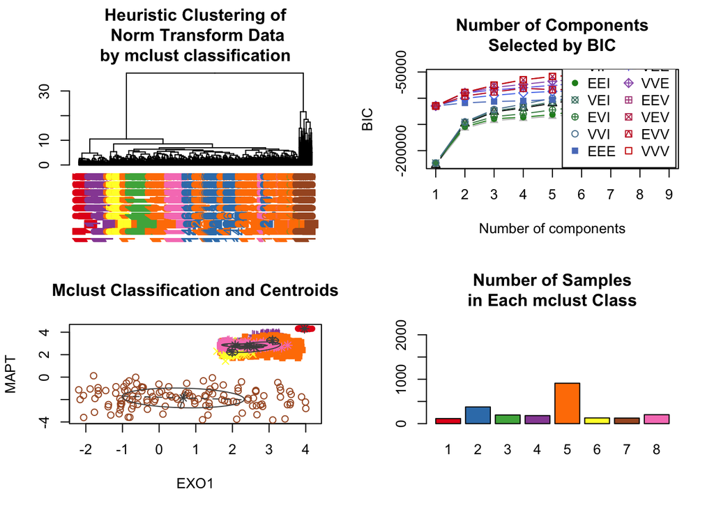

```
## 'Mclust' model object:
##  best model: ellipsoidal, equal shape (VEV) with 8 components
```

```r
#===================================# Task 2 #=====================================#
#normalize each study
data.norm <- vector("list", 17)
data.norm[1:11] <- lapply(1:11, function(i) {datn1 <-as.data.frame(data.uncat[[i]])
                                              ctsn=log2(datn1+1)
                                                  return(ctsn)})
data.norm[[12]] <- data.uncat[[12]]
data.norm[13:17]<- lapply(13:length(dat), function(i) {datn1 <-as.data.frame(data.uncat[[i]])
                                              ctsn=log2(datn1+1)
                                                  return(ctsn)})
#concatonate the normtransformed datasets
data.normcat <- do.call(cbind, data.norm)

#apply function to norm transformed data
clustering2(data.normcat, "Norm Transform")
```

## Task 3: Clustering within Quantile Normalized Concatenated Dataset

The quantile normalization is the most heavy handed type of normalization, in which quantiles from all 17 studies were forced to match.

```r
#===================================# Task 3 #=====================================#
# Quantile Normalization each study, concatenate, run hclust /mclust
#source("https://bioconductor.org/biocLite.R")

#concatenate, run quantile normalization, take log (then transpose as needed), then run hclust /mclust
#normalize.quantiles(x,copy=TRUE) package: PreprocessCore
library(preprocessCore)

data.quant <- vector("list", 17)
for(i in c(1:11, 13:17)){
data.quant[[i]] <- log2(data.uncat[[i]] + 1)
}
data.quant[[12]] <- data.uncat[[12]]

# performing quantile normalization within each study (using normalization in blocks within the contatenated dataset)
data.ncat1 <- Reduce(function(x,y) t(merge(t(x),t(y),all=T)), data.quant)

block.size <- sapply(1:length(data.quant), function(i) dim(data.quant[[i]])[2])
data.qnormcat0 <- normalize.quantiles.in.blocks(t(data.ncat1), blocks=rep(1:17, times=block.size))
data.qnormcat <- t(data.qnormcat0)
# clustering with hclust and mclust
c <- clustering2(data.qnormcat, "Quantile Normalized")
```

[figure not shown]

## Task 4: Clustering within Batch Mean Centered Concatonated Dataset

In this task we are interested in transforming the data by the method called `Batch Mean Centering`. Batch mean centering transforms the observation $x_{ij}^k$ from gene $i$, sample $j$ and study $k$ by the formula:
$$\hat{x}_{ij}^k = x_{ij}^k - \bar{x}_i^k$$
Each study is first transformed by doing a $\log2$ normalization and then we take the mean $\bar{x}_i^k$ within each gene and each study. After that we use the original observation to subtract the computed mean to finish the transformation.

We first compute the $\bar{x}_i^k, k = 1 ,\cdots, 17$, which is the row mean corresponding to the design matrix of each study. We assign it to a list of $17$ elements.

```r
#===================================# Task 4 #=====================================#
# Batch Mean Censoring each study, concatenate, run hclust
# calculate the batch mean with respect to the 35 genes
data.rowmean = lapply(data.norm, function(data) apply(data, 1, mean))
# subtract the mean
```

Next, we subtract the row mean vector from the original matrix of each study rowwisely. We get a list of 17 unconcatenated matrices and after that we concatenate those 17 matrices together to get the matrix transformed from `BMC` and then again run the `clustering2` on the transformed matrix:

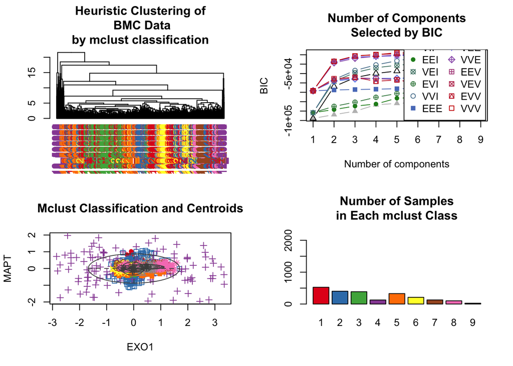

```
## 'Mclust' model object:
##  best model: diagonal, varying volume and shape (VVI) with 9 components
```

```r
data.bmcuncat = lapply(1:length(data.norm), function(ix) data.norm[[ix]] - data.rowmean[[ix]])
# concatenate the 17 bmc normalized dataset
data.bmccat <- do.call(cbind, data.bmcuncat)
set.seed(706)
clustering2(data.bmccat, "BMC")
```

## Task 5: Clustering within ComBat Transformed Dataset

In this task we are interested in transforming the data by the method called `ComBat`. The transformation is fulfilled by the R package `sva`. The general idea behind ComBat transformation is that it estimates the parameters of a model for mean and variance for each gene and then adjusts the genes in each batch to meet the assumed model:
$$x_{ij}^k = \alpha_i + C \beta_i + \gamma_i^k + \delta_i^k \epsilon_{ij}^k.$$
The theory that backs up this model is Empirical Bayes. As in the last task, we first transform the data by the $\log2$ transformation. We generate the study id in a vector as one input in the function `ComBat` as we show below:

```r
#ComBat transform
# ComBat: concatenate the norm transformed data (data.normcat) and the quantile normalized data (data.qnormcat) and then run ComBat on the data set to adjust for batch effects, treat each study as a known batch.
library(sva)
batch.id.list = lapply(1:length(data.uncat), function(batch.id) rep(batch.id, ncol(data.uncat[[batch.id]])))
batch.id.unlist = as.factor(unlist(batch.id.list))
```

Using the function `ComBat`, we adjust for the batch (study) effects from the $\log 2$ transformed concatenated data matrix and the output gives the transformed concatenated data matrix using ComBat `data.normComBat`. After that, as before, we use the function `clustering2` to generate the clustering results from `hclust` and `mclustBIC`:

```r
data.normComBat <- ComBat(data.normcat, batch.id.unlist, par.prior = TRUE, prior.plots = FALSE, mean.only = FALSE, ref.batch = NULL, BPPARAM = bpparam("SerialParam"))
```

```
## Standardizing Data across genes
```

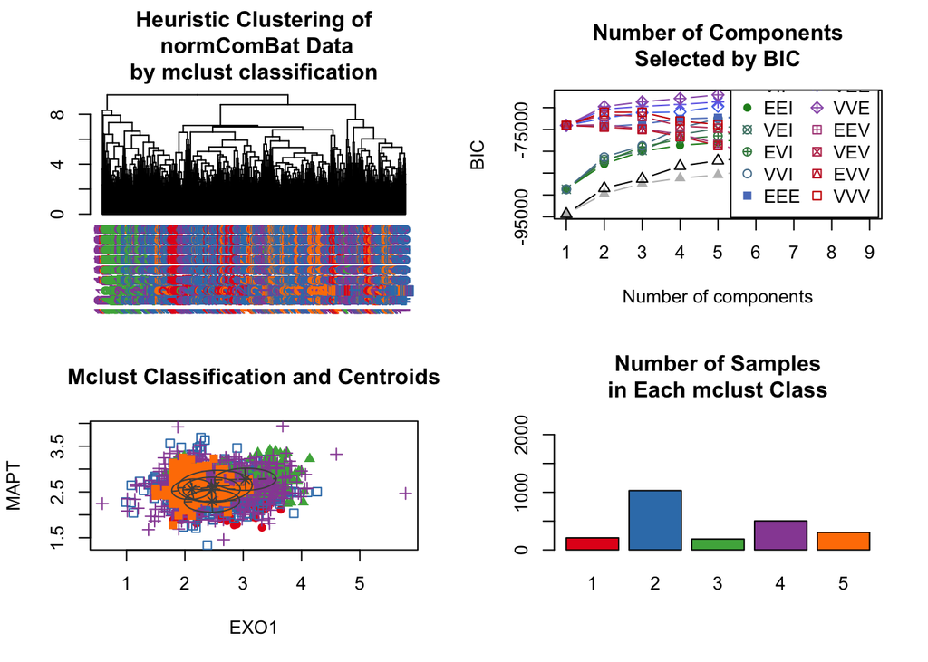

```
## 'Mclust' model object:
##  best model: ellipsoidal, equal orientation (VVE) with 5 components
```

```r
clustering2(data.normComBat, "normComBat")
```

From the Figure above, we can see that the heuristic clustering and the mclustering give similar results. An interesting fact to notice is that the lower left graph of this figure compared to the last one, does not have an obvious outlier cluster outside of where the other clusters are located, meaning that the Combat method adjusts for the batch effects pretty well. The optimal cluster number given by BIC based on this transformation method is 5, which does not agree with the 3 clusters claimed by the paper’s algorithm. However the true number of subtypes is 5.

# References

1. Planey CR and Gevaert O. “CoINcIDE: A framework for discovery of patient subtypes across multiple datasets”. Genome Medicine. 2016; 8:27